# Reproducible Research: Peer Assessment 1

## Loading and preprocessing the data

```r
library(ggplot2)
library(Hmisc)
temp <- tempfile()
setInternet2(use = TRUE)
download.file("https://d396qusza40orc.cloudfront.net/repdata%2Fdata%2Factivity.zip", temp)
data <- read.csv(unz(temp, "activity.csv"))
unlink(temp)
newdata<-data
newdata$interval<- strptime(gsub("([0-9]{1,2})([0-9]{2})", "\\1:\\2", newdata$interval), format='%H:%M')
```

## What is mean total number of steps taken per day?

1.Calculate the total number of steps taken per day

```r
StepsPerDay<-tapply(newdata$steps, newdata$date, FUN=sum, na.rm= TRUE)
```

2.Make a histogram of the total number of steps taken each day

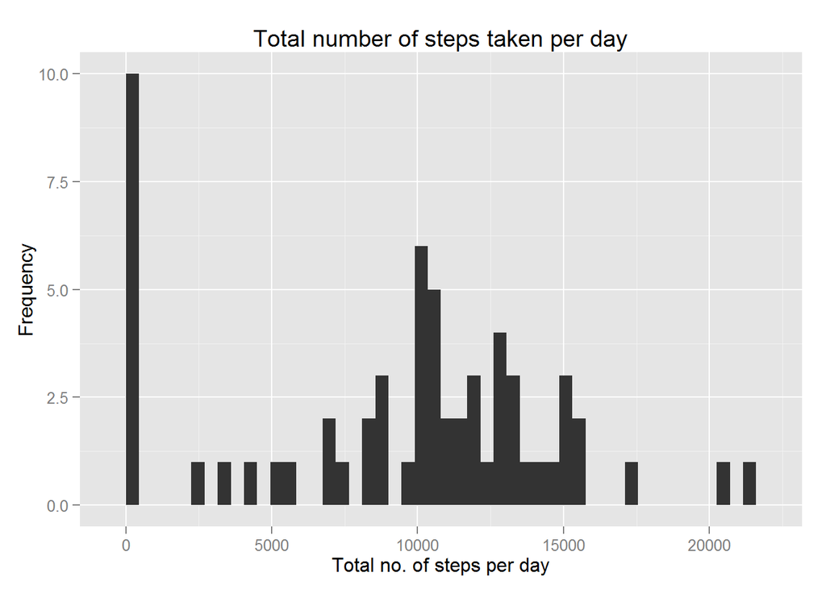

```r
qplot(StepsPerDay, xlab="Total no. of steps per day", ylab = "Frequency", binwidth=450,main="Total number of steps taken per day")
```

3.Calculate and report the mean and median of the total number of steps taken per day

```r
MeanOfSteps<-mean(StepsPerDay)
MedianOfSteps<-median(StepsPerDay)
```

The mean of the total number of steps taken per day is 9354.2295082.

The median of the total number of steps taken per day is 10395.

## What is the average daily activity pattern?

```r
Averagesteps<-aggregate(data$steps~data$interval,data,FUN=mean,na.rm=TRUE)
names(Averagesteps)<-cbind("interval","steps")
```

1.Make a time series plot (i.e. type = “l”) of the 5-minute interval (x-axis) and the average number of steps taken, averaged across all days (y-axis)

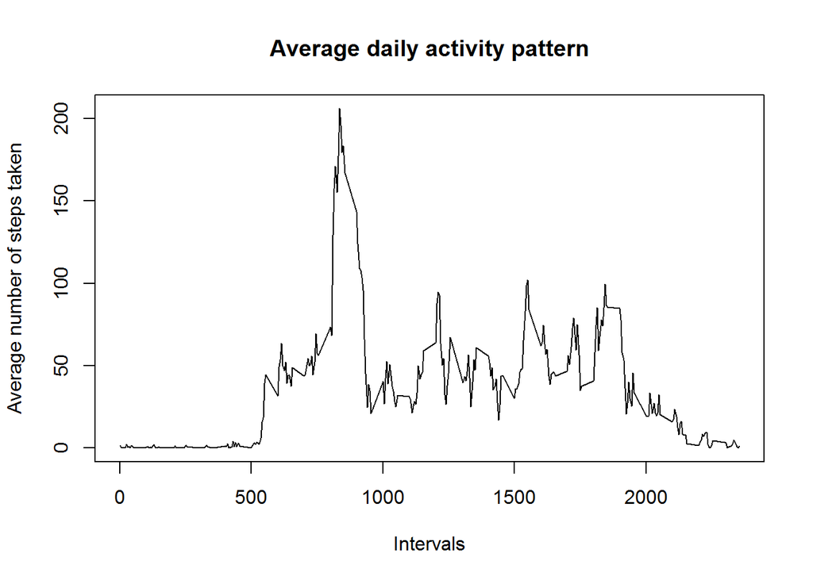

```r
plot(Averagesteps$interval,Averagesteps$steps, type="l",ylab="Average number of steps taken", xlab="Intervals",main="Average daily activity pattern")
```

```r
MaxSteps<-which.max(Averagesteps$steps)
IntervalMaxSteps<-gsub("([0-9]{1,2})([0-9]{2})", "\\1:\\2", Averagesteps[MaxSteps,'interval'])
```

## Imputing missing values

```r
NumOfMissingValues<-sum(is.na(data$steps))
```

2.Devise a strategy for filling in all of the missing values in the dataset. 3.Create a new dataset that is equal to the original dataset but with the missing data filled in.

```r
UpdatedData<-data
UpdatedData$steps <-with(data, impute(steps,mean))
```

4.Make a histogram of the total number of steps taken each day

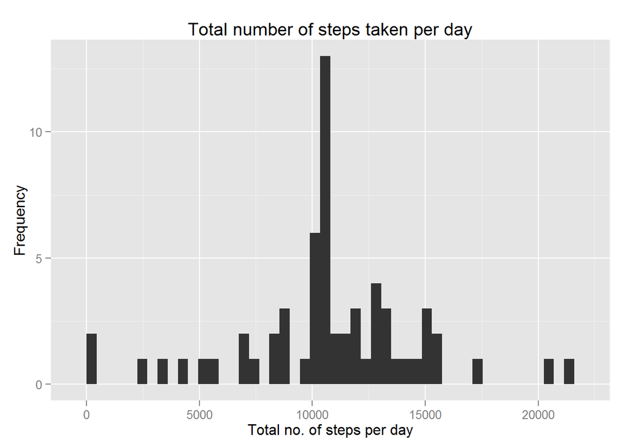

```r
TotalStepsPerDay<- tapply(UpdatedData$steps,UpdatedData$date, FUN=sum)
qplot(TotalStepsPerDay, xlab="Total no. of steps per day", ylab = "Frequency", binwidth=450,main="Total number of steps taken per day")
```

```r
MeanTotalSteps<-mean(TotalStepsPerDay)
MedianTotalSteps<-median(TotalStepsPerDay)
```

## Are there differences in activity patterns between weekdays and weekends?

1.Create a new factor variable in the dataset with two levels - “weekday” and “weekend” indicating whether a given date is a weekday or weekend day.

```r
 UpdatedData$day<-ifelse(as.POSIXlt(UpdatedData$date)$wday %in% c(0,6), 'weekend','weekday')
```

2.Make a panel plot containing a time series plot (i.e. type = “l”) of the 5-minute interval (x-axis) and the average number of steps taken, averaged across all weekday days or weekend days (y-axis).

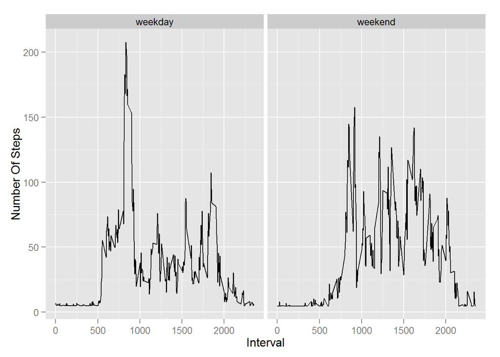

```r
NewAveragesteps<-aggregate(UpdatedData$steps~UpdatedData$interval+UpdatedData$day,UpdatedData,FUN=mean)
names(NewAveragesteps)<-cbind("Interval","day","NumberOfSteps")
g<-ggplot(NewAveragesteps, aes(Interval,NumberOfSteps))
p<-g+geom_line()+facet_grid(.~day)+labs(y="Number Of Steps")
print(p)
```